# Project 3

Premier League data

Sciper 359523

# 1 Introduction

Home advantage is a well-known phenomenon in football, where a team playing at their home stadium has an advantage over the away team. This advantage can be attributed to factors such as familiarity with the playing surface and surroundings, support of home fans, and a psychological boost. In addition, referees may also be influenced by the home crowd, which is known as refereeing bias. A study by Garicano and Palacios-Huerta (2001)[1] found that home teams in the Spanish La Liga received significantly fewer yellow and red cards than away teams, suggesting that referees may be influenced by the home crowd.

The magnitude of the home advantage effect has been highlighted by previous studies. Nevill, Newell, and Gale (1996) [2] analyzed over 10,000 matches from English football leagues and found that home teams won approximately 60% of matches, while away teams won only 20% of matches. A more recent study by Pollard [3] analyzed data from the UEFA Champions League and concluded that home teams won 62.4% of matches, while away teams won only 20.3% of matches.

In this project, we analyze the English Premier League during the seasons 2018-2019 to 2021-2022. Due to Covid-19, teams were forced to play in empty stadiums between March 2020 and the beginning of the 2021-22 season. This presents an opportunity to investigate the strength of the home advantage effect during closed-door matches, where neither the players nor the referees are influenced by the crowd. Thus, this report will present the most significant results concerning the effect of Covid-19 on home advantage.

In Section 2, we introduce the dataset, and in Section 3, we describe two models to account for the home advantage and analyze their residuals. Section 4 analyzes stability of the final model. In Section 5, we interpret and analyze the coefficients and the results of the models, and finally, we conclude the work done and discuss potential improvements in Section 6.

# 2 Data characteristics

The data used for analysis consists of match results and statistics, betting odds, and bookmaker information from the English Premier League. The data set contains match results for four seasons : 2018-2019, 2019-2020, 2020-2021, and 2021-2022. The match results variables include the winning team, home and away teams, goals scored by each team at half-time and full-time, the number of shots and shots on target, as well as yellow and red cards for each team. In addition, the data set includes information on the number of BetBrain bookmakers used to calculate match odds averages and maximums, and total goals betting odds.

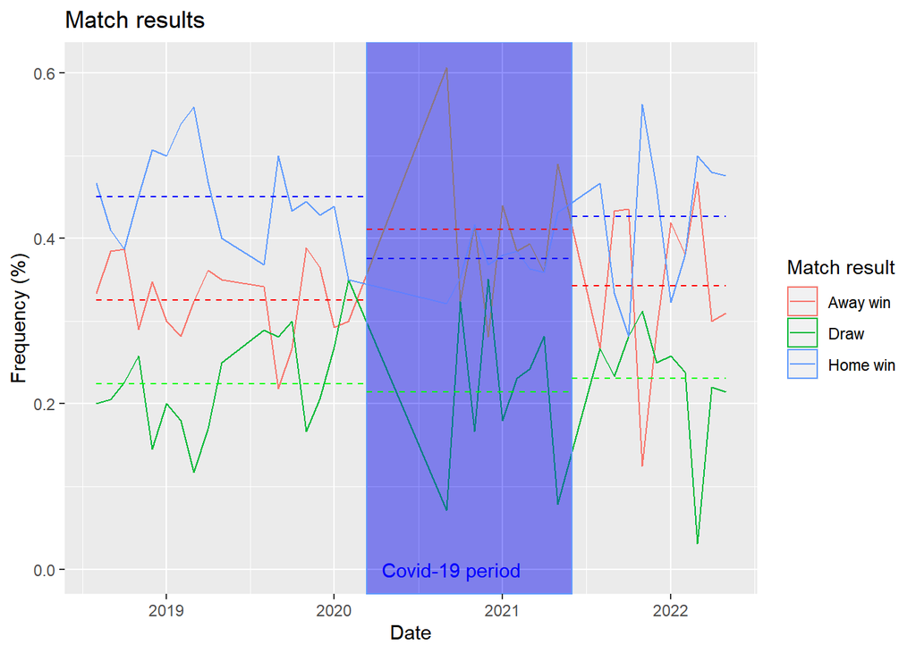

Figure 1 : Match results according to the team status

Figure 1 provides a visual representation of the distribution of home wins, away wins, and draws during three distinct periods: pre-covid, during-covid, and post-covid. The dashed lines represent the average percentage of each outcome for each period. The data shows that before and after the period of closed-door matches, the proportion of home wins significantly outweighed that of away wins. However, during the covid-19 period, the difference between home and away wins decreased, and there was even a slight preference for away teams. These findings suggest that the presence of supporters could play a significant role in a team’s performance, as they are more likely to win when playing in front of a full stadium.

In the next section, we model the data to gain a deeper understanding of the extent to which the home advantage persisted during the COVID-19 pandemic. As a first definition of home advantage, we primarily examine the impact of playing at home on a team’s goal scoring ability with a poisson model. Secondly, we use the red cards to build another poisson model. Our analysis aims to provide robust evidence on the impact of playing without fans and whether it affected the home advantage in the English Premier League.

# 3 Model building

## 3.1 Poisson model on the number of goals

Home advantage can manifest in various forms, and we consider one indicator to be a team scoring more goals when playing at home. We construct a global Poisson model to evaluate the effect of playing at home on a team’s goal scoring ability and the COVID-19 effect. In this model are included the following variables : the number of goals scored, the team playing home and the adverse team, a binary indicator of whether the team is playing home or away, an indicator of the COVID-19 period having levels corresponding to before,during and after. Finally, we include a cross term between the indicator of playing home or away and the indicator of the COVID-19 period. In the first model that I had built, I had also put the referee variable, to account for the fact that some referees can be stricter than others. But, the associated coefficients are not significant, thus, I discarded this variable in the final model previously described.

The poisson model can be written with the following equation

$$log(\mathbb{E}(N_{goals})) = \beta^{T}X
+ \epsilon$$

where $\beta$ is a vector containing the estimated coefficients, $X$ is the design matrix, $\epsilon$ is the residual, and $N_{goals}$ is the number of goals.

The estimated coefficients of the model are in the following table:

*Table1 : Estimated coefficients*

|  | Estimate | Std.Error | t value | Pr(>\|t\|) | 2.5% | 97.5% |
| --- | --- | --- | --- | --- | --- | --- |
| Playing Home | 0.008 | 0.06 | 0.13 | 0.9 | -0.11 | 0.13 |
| Pre-covid*(Playing Home) | 0.19 | 0.08 | 2.37 | 0.02 | 0.03 | 0.34 |
| Post-covid*(Playing Home) | 0.14 | 0.08 | 1.59 | 0.11 | -0.03 | 0.31 |

## 3.2 Residuals diagnostics

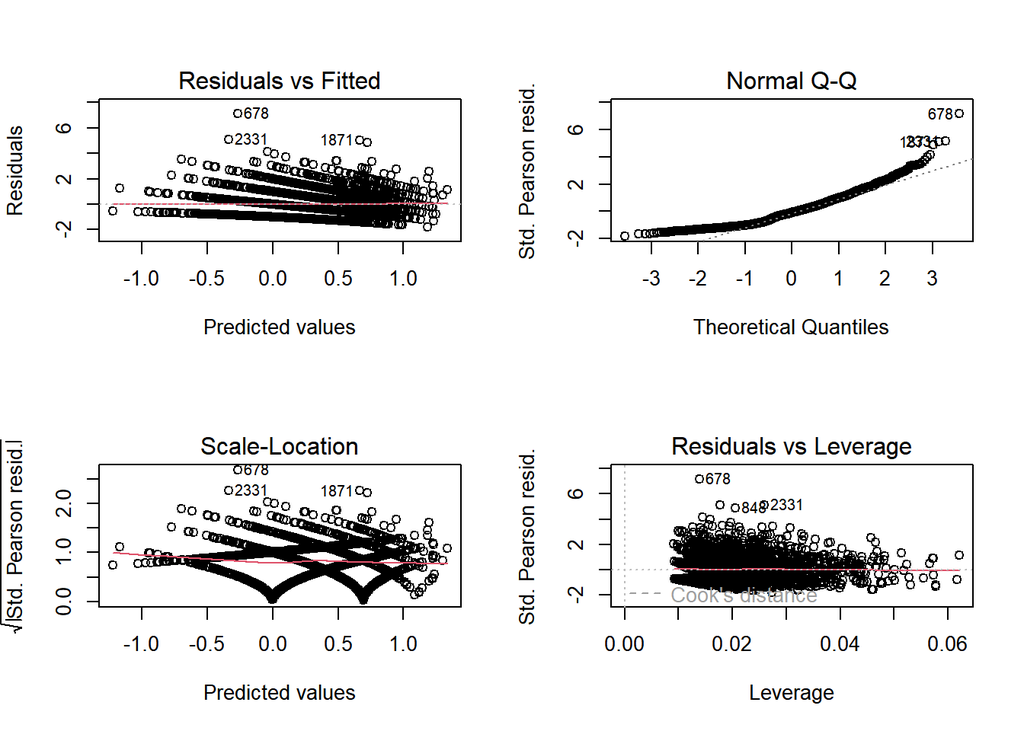

## 3.3 Poisson model on the number of red cards

In the previous model, we explored the number of goals scored as an indicator of the home advantage. But, some studies [1] also investigated the number of red or yellow cards a team receives as an indicator of the home advantage. A team that is in difficulty will tend to do more faults and thus will be more likely to receive yellow or red cards. Moreover, having the support of the crowd in the stadium can influence the referees into sanctioning by a red or a yellow card some players. Thus, I build another poisson model with the same covariates as previously and obtain the following results (Referee is still not significant so I discarded it again).

The estimated coefficients of the model are in the following table:

*Table2 : Estimated coefficients*

|  | Estimate | Std.Error | t value | Pr(>\|t\|) |
| --- | --- | --- | --- | --- |
| Playing Home | - 0.35 | 0.29 | -1.17 | 0.24 |
| Pre-covid*(Playing Home) | 0.05 | 0.38 | 0.12 | 0.90 |
| Post-covid*(Playing Home) | 0.12 | 0.43 | 0.275 | 0.78 |

## 3.4 Residuals

The residuals presented in *Figure 4* present the characteristic bands of the Poisson model. However, the QQplot doesn’t seem normal at all and many outliers are visible. The model doesn’t seem as good as the previous one.

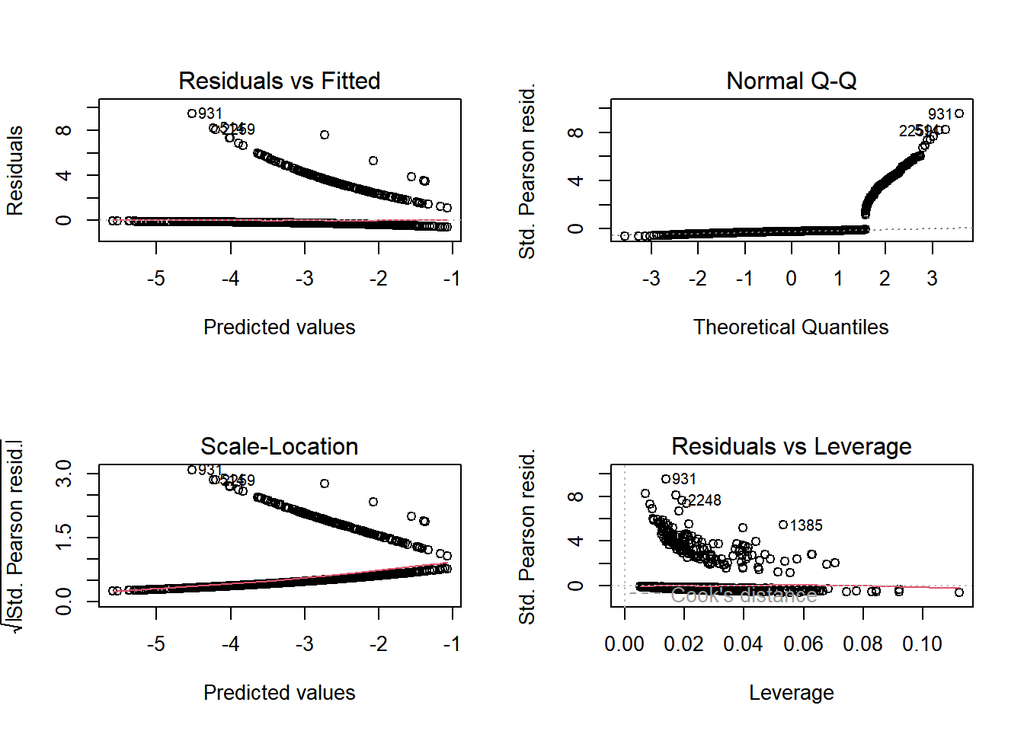

Figure 4: Residuals diagnostics for the red cards model

# 4 Stability

The model we have built so far have not taken into account the fact that some teams are relegated and others are promoted from season to season, which could potentially impact the estimates of the coefficients. To address this, we discard those teams and refit the Poisson model. This new model takes into account only the teams that have participated in all four seasons, and the estimated coefficients are based on these teams only. The estimated coefficients for the remaining teams are presented in the following table:

*Table 3 : Estimated coefficients of the Poisson model without relegated and promoted teams*

|  | Estimate | Std.Error | t value | Pr(>\|t\|) |
| --- | --- | --- | --- | --- |
| Playing Home | -0.017 | 0.08 | 0.2 | 0.83 |
| Pre-covid*(Playing Home) | 0.16 | 0.10 | 1.49 | 0.13 |
| Post-covid*(Playing Home) | 0.23 | 0.12 | 1.94 | 0.05 |

# 5 Interpretation

The second approach considers the number of red cards for each team and models it again using a Poisson regression. The estimated coefficient associated to playing home is negative which makes sense since a team is advantaged if it receives less red cards. The effect associated with the cross terms between playing home and the covid periods are not significant at the 5% level which means that there is no effect associated with the different covid periods. This could mean that independently on the crowd in the stadium, teams are advantaged the same way regarding red cards.

We included teams in both models to account for their individual impact. In the goals model, as a result, less successful teams have negative coefficients, while the most successful teams in the English Premier League have positive coefficients. For instance, the team associated coefficient of Manchester City, the 2021-22 tournament winner, is the highest at 0.41 (when playing home) and is statistically significant at all levels. Conversely, Norwich, which ranked last in the 2021-22 English Premier League, has a strongly negative coefficient of -0.75 (again when being the home team), which is also statistically significant at all levels.

The confidence intervals for parameters were computed with the usual *confint* function. The interpretation is as follows : if 0 belongs to the confidence interval, the coefficient is not statistically significant, but otherwise, the coefficient is statistically significant. If the confidence interval is very wide, then, the coefficient is not practically significant since it varies in a very dispersed range of values. Considering the goals model, the confidence intervals we have show that the coefficient associated with the pre-covid period is statistically significant whereas the coefficient associated with the post-covid period is not.

# 6 Discussion

The goals model developed shows a greater effect of home advantage before the COVID-19 pandemic compared to during of after the closed-doors period due to the closure of public stadiums. Since the stadiums’ grass didn’t change, the most plausible explanation of this decrease is the absence of supporters that can influence the players and the referees. That hypothesis seems the most relevant since after the pandemic, the estimated home advantage is positive and sometimes at the edge of statistical significance. The magnitude of the effect was generally similar although slightly smaller. Possible explanations for this slight decrease include teams becoming accustomed to playing in empty stadiums or changes in fan behavior before and after the pandemic.

The stability analysis shows that the model is not that robust since the coefficients are not significant when only taking into account the teams that are not promoted nor relegated. Moreover, when looking at the residuals, as previously stated, some influential outliers were identified which can possibly slightly bias the models we built. As a deepening of this work, one could therefore refit the models without those outliers.

Another deepening would be to explore other definitions of the home advantage and other indicators. Indeed, we did the red cards, which was studied by Garicano and Palacios-Huertas [1], but we did not take into account the yellow cards that we could also model with a Poisson model. We could even for example give as a rule that a yellow card is half the value of a red one and combine the two indicators into one. Additionally, while we analyzed the number of goals, it could also be interesting to investigate a wider indicator such as the number of targeted goals instead.

# 7 References

[1] Garicano, L. and Palacios-Huerta, I. (2001). “An empirical examination of multilateral bargaining.” American Economic Review, 91(4): 828-848.

[2] Nevill, A. M., Newell, S. M., & Gale, S. (1996). Factors associated with home advantage in English and Scottish soccer matches. Journal of Sports Sciences, 14(2), 181-186.

[3] Pollard, R., & Pollard, G. (2005). Home advantage in soccer: Variations in its magnitude and a literature review of the inter-related factors associated with its existence. Journal of Sport Behavior, 28(3), 169-189.

[4] Stensrud M, ‘Randomization and Causation’ course, EPFL

[5] Davezzies L, Visser M, Lapenta E, D’Hautefoeuille X, ‘Econometrics 1’ and ‘Econometrics 2’ course, ENSAE Paris